# Vector Complex Mult

# Vector Complex Mult

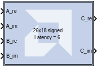

## Description

The Vector Complex Multiplier block supports multiplication of two complex input vectors.

## Parameters

#### SSR

Use this parameter to control processing of multiple data samples on every sample period.

## Output Data Type Interpretation

- The output data type is always set to signed fixed-point with a word length of 44 bits and and no fractional component (i.e., a fractional length of 0 bits).
- The user is responsible for correctly reinterpreting the output data type based on the input binary points.
- For example, if the input data types for Port A and Port B are Fix_26_23 (word length = 26, fractional length = 23) and Fix_18_16 respectively, then the expected fractional length of the output will be 39 (23 + 16).

**Note**: Use the Reinterpret block to convert the output data type as needed.

## Examples

**Click on the images below to open each model.**

[figure not shown]

Copyright (C) 2026 Advanced Micro Devices, Inc. All rights reserved.

SPDX-License-Identifier: MIT